# Risk Factor Analysis

## Outcome Variable

**Outcome Variable:** swasted

## Predictor Variables

**Intervention Variable:** fage

**Adjustment Set:**

unadjusted

## Stratifying Variables

The analysis was stratified on these variable(s):

- agecat
- studyid
- country

## Data Summary

| agecat | studyid | country | fage | swasted | n_cell | n |
| --- | --- | --- | --- | --- | --- | --- |
| Birth | ki0047075b-MAL-ED | BANGLADESH | >=38 | 0 | 58 | 128 |
| Birth | ki0047075b-MAL-ED | BANGLADESH | >=38 | 1 | 3 | 128 |
| Birth | ki0047075b-MAL-ED | BANGLADESH | <32 | 0 | 22 | 128 |
| Birth | ki0047075b-MAL-ED | BANGLADESH | <32 | 1 | 1 | 128 |
| Birth | ki0047075b-MAL-ED | BANGLADESH | [32-38) | 0 | 42 | 128 |
| Birth | ki0047075b-MAL-ED | BANGLADESH | [32-38) | 1 | 2 | 128 |
| Birth | ki0047075b-MAL-ED | BRAZIL | >=38 | 0 | 5 | 16 |
| Birth | ki0047075b-MAL-ED | BRAZIL | >=38 | 1 | 0 | 16 |
| Birth | ki0047075b-MAL-ED | BRAZIL | <32 | 0 | 1 | 16 |
| Birth | ki0047075b-MAL-ED | BRAZIL | <32 | 1 | 0 | 16 |
| Birth | ki0047075b-MAL-ED | BRAZIL | [32-38) | 0 | 10 | 16 |
| Birth | ki0047075b-MAL-ED | BRAZIL | [32-38) | 1 | 0 | 16 |
| Birth | ki0047075b-MAL-ED | INDIA | >=38 | 0 | 7 | 25 |
| Birth | ki0047075b-MAL-ED | INDIA | >=38 | 1 | 0 | 25 |
| Birth | ki0047075b-MAL-ED | INDIA | <32 | 0 | 8 | 25 |
| Birth | ki0047075b-MAL-ED | INDIA | <32 | 1 | 0 | 25 |
| Birth | ki0047075b-MAL-ED | INDIA | [32-38) | 0 | 10 | 25 |
| Birth | ki0047075b-MAL-ED | INDIA | [32-38) | 1 | 0 | 25 |
| Birth | ki0047075b-MAL-ED | NEPAL | >=38 | 0 | 2 | 9 |
| Birth | ki0047075b-MAL-ED | NEPAL | >=38 | 1 | 0 | 9 |
| Birth | ki0047075b-MAL-ED | NEPAL | <32 | 0 | 2 | 9 |
| Birth | ki0047075b-MAL-ED | NEPAL | <32 | 1 | 0 | 9 |
| Birth | ki0047075b-MAL-ED | NEPAL | [32-38) | 0 | 4 | 9 |
| Birth | ki0047075b-MAL-ED | NEPAL | [32-38) | 1 | 1 | 9 |
| Birth | ki0047075b-MAL-ED | PERU | >=38 | 0 | 23 | 67 |
| Birth | ki0047075b-MAL-ED | PERU | >=38 | 1 | 0 | 67 |
| Birth | ki0047075b-MAL-ED | PERU | <32 | 0 | 21 | 67 |
| Birth | ki0047075b-MAL-ED | PERU | <32 | 1 | 0 | 67 |
| Birth | ki0047075b-MAL-ED | PERU | [32-38) | 0 | 23 | 67 |
| Birth | ki0047075b-MAL-ED | PERU | [32-38) | 1 | 0 | 67 |

[output cut: 180 more lines]

The following strata were considered:

- agecat: 24 months, studyid: ki0047075b-MAL-ED, country: BANGLADESH
- agecat: 24 months, studyid: ki0047075b-MAL-ED, country: BRAZIL
- agecat: 24 months, studyid: ki0047075b-MAL-ED, country: INDIA
- agecat: 24 months, studyid: ki0047075b-MAL-ED, country: NEPAL
- agecat: 24 months, studyid: ki0047075b-MAL-ED, country: PERU
- agecat: 24 months, studyid: ki0047075b-MAL-ED, country: SOUTH AFRICA
- agecat: 24 months, studyid: ki0047075b-MAL-ED, country: TANZANIA, UNITED REPUBLIC OF
- agecat: 24 months, studyid: ki1119695-PROBIT, country: BELARUS
- agecat: 24 months, studyid: ki1135781-COHORTS, country: GUATEMALA
- agecat: 24 months, studyid: ki1135781-COHORTS, country: PHILIPPINES
- agecat: 24 months, studyid: ki1148112-LCNI-5, country: MALAWI
- agecat: 6 months, studyid: ki0047075b-MAL-ED, country: BANGLADESH
- agecat: 6 months, studyid: ki0047075b-MAL-ED, country: BRAZIL
- agecat: 6 months, studyid: ki0047075b-MAL-ED, country: INDIA
- agecat: 6 months, studyid: ki0047075b-MAL-ED, country: NEPAL
- agecat: 6 months, studyid: ki0047075b-MAL-ED, country: PERU
- agecat: 6 months, studyid: ki0047075b-MAL-ED, country: SOUTH AFRICA
- agecat: 6 months, studyid: ki0047075b-MAL-ED, country: TANZANIA, UNITED REPUBLIC OF
- agecat: 6 months, studyid: ki1000304b-SAS-CompFeed, country: INDIA
- agecat: 6 months, studyid: ki1000304b-SAS-FoodSuppl, country: INDIA
- agecat: 6 months, studyid: ki1119695-PROBIT, country: BELARUS
- agecat: 6 months, studyid: ki1135781-COHORTS, country: GUATEMALA
- agecat: 6 months, studyid: ki1135781-COHORTS, country: PHILIPPINES
- agecat: 6 months, studyid: ki1148112-LCNI-5, country: MALAWI
- agecat: Birth, studyid: ki0047075b-MAL-ED, country: BANGLADESH
- agecat: Birth, studyid: ki0047075b-MAL-ED, country: BRAZIL
- agecat: Birth, studyid: ki0047075b-MAL-ED, country: INDIA
- agecat: Birth, studyid: ki0047075b-MAL-ED, country: NEPAL
- agecat: Birth, studyid: ki0047075b-MAL-ED, country: PERU
- agecat: Birth, studyid: ki0047075b-MAL-ED, country: SOUTH AFRICA
- agecat: Birth, studyid: ki0047075b-MAL-ED, country: TANZANIA, UNITED REPUBLIC OF
- agecat: Birth, studyid: ki1000304b-SAS-CompFeed, country: INDIA
- agecat: Birth, studyid: ki1119695-PROBIT, country: BELARUS
- agecat: Birth, studyid: ki1135781-COHORTS, country: GUATEMALA
- agecat: Birth, studyid: ki1135781-COHORTS, country: PHILIPPINES

### Dropped Strata

Some strata were dropped due to rare outcomes:

- agecat: Birth, studyid: ki0047075b-MAL-ED, country: BANGLADESH
- agecat: Birth, studyid: ki0047075b-MAL-ED, country: BRAZIL
- agecat: Birth, studyid: ki0047075b-MAL-ED, country: INDIA
- agecat: Birth, studyid: ki0047075b-MAL-ED, country: NEPAL
- agecat: Birth, studyid: ki0047075b-MAL-ED, country: PERU
- agecat: Birth, studyid: ki0047075b-MAL-ED, country: SOUTH AFRICA
- agecat: Birth, studyid: ki0047075b-MAL-ED, country: TANZANIA, UNITED REPUBLIC OF
- agecat: Birth, studyid: ki1000304b-SAS-CompFeed, country: INDIA
- agecat: 6 months, studyid: ki0047075b-MAL-ED, country: BANGLADESH
- agecat: 6 months, studyid: ki0047075b-MAL-ED, country: BRAZIL
- agecat: 6 months, studyid: ki0047075b-MAL-ED, country: INDIA
- agecat: 6 months, studyid: ki0047075b-MAL-ED, country: NEPAL
- agecat: 6 months, studyid: ki0047075b-MAL-ED, country: PERU
- agecat: 6 months, studyid: ki0047075b-MAL-ED, country: SOUTH AFRICA
- agecat: 6 months, studyid: ki0047075b-MAL-ED, country: TANZANIA, UNITED REPUBLIC OF
- agecat: 6 months, studyid: ki1000304b-SAS-CompFeed, country: INDIA
- agecat: 6 months, studyid: ki1000304b-SAS-FoodSuppl, country: INDIA
- agecat: 6 months, studyid: ki1119695-PROBIT, country: BELARUS
- agecat: 6 months, studyid: ki1135781-COHORTS, country: GUATEMALA
- agecat: 6 months, studyid: ki1148112-LCNI-5, country: MALAWI
- agecat: 24 months, studyid: ki0047075b-MAL-ED, country: BANGLADESH
- agecat: 24 months, studyid: ki0047075b-MAL-ED, country: BRAZIL
- agecat: 24 months, studyid: ki0047075b-MAL-ED, country: INDIA
- agecat: 24 months, studyid: ki0047075b-MAL-ED, country: NEPAL
- agecat: 24 months, studyid: ki0047075b-MAL-ED, country: PERU
- agecat: 24 months, studyid: ki0047075b-MAL-ED, country: SOUTH AFRICA
- agecat: 24 months, studyid: ki0047075b-MAL-ED, country: TANZANIA, UNITED REPUBLIC OF
- agecat: 24 months, studyid: ki1119695-PROBIT, country: BELARUS
- agecat: 24 months, studyid: ki1135781-COHORTS, country: GUATEMALA
- agecat: 24 months, studyid: ki1135781-COHORTS, country: PHILIPPINES
- agecat: 24 months, studyid: ki1148112-LCNI-5, country: MALAWI

## Methods Detail

We’re interested in the causal parameters $E[Y_a]$ for all values of $a \in \mathcal{A}$. These parameters represent the mean outcome if, possibly contrary to fact, we intervened to set all units to have $A=a$. Under the randomization and positivity assumptions, these are identified by the statistical parameters $\psi_a=E_W[E_{Y|A,W}(Y|A=a,W)]$. In addition, we’re interested in the mean of $Y$, $E[Y]$ under no intervention (the observed mean). We will estimate these parameters by using SuperLearner to fit the relevant likelihood factors – $E_{Y|A,W}(Y|A=a,W)$ and $p(A=a|W)$, and then updating our likelihood fit using a joint TMLE.

For unadjusted analyses ($W=\{\}$), initial likelihoods were estimated using Lrnr_glm to estimate the simple $E(Y|A)$ and Lrnr_mean to estimate $p(A)$. For adjusted analyses, a small library containing Lrnr_glmnet, Lrnr_xgboost, and Lrnr_mean was used.

Having estimated these parameters, we will then use the delta method to estimate relative risks and attributable risks relative to a prespecified baseline level of $A$.

# Results Detail

## Results Plots

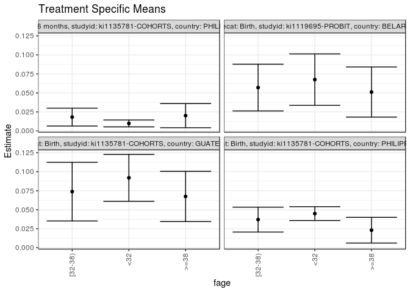

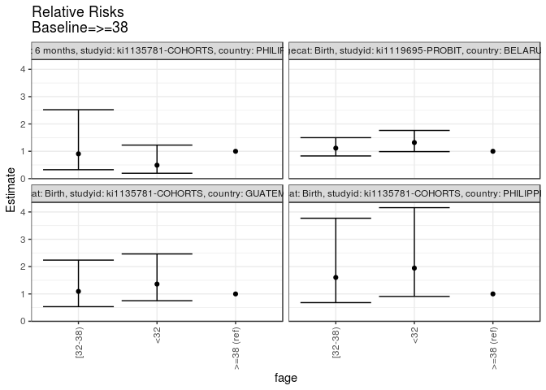

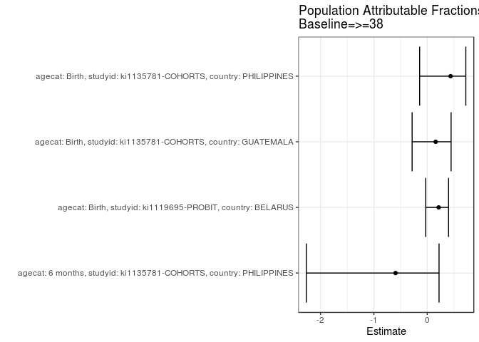

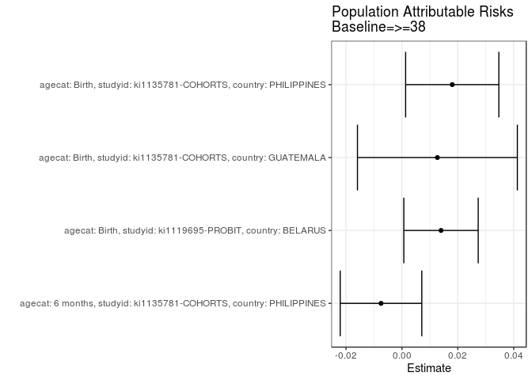

## Results Table

### Parameter: TSM

| agecat | studyid | country | intervention_level | baseline_level | estimate | ci_lower | ci_upper |
| --- | --- | --- | --- | --- | --- | --- | --- |
| Birth | ki1119695-PROBIT | BELARUS | >=38 | NA | 0.0511551 | 0.0181920 | 0.0841182 |
| Birth | ki1119695-PROBIT | BELARUS | <32 | NA | 0.0675030 | 0.0336449 | 0.1013612 |
| Birth | ki1119695-PROBIT | BELARUS | [32-38) | NA | 0.0570175 | 0.0262508 | 0.0877843 |
| Birth | ki1135781-COHORTS | GUATEMALA | >=38 | NA | 0.0675676 | 0.0345272 | 0.1006080 |
| Birth | ki1135781-COHORTS | GUATEMALA | <32 | NA | 0.0919881 | 0.0611108 | 0.1228655 |
| Birth | ki1135781-COHORTS | GUATEMALA | [32-38) | NA | 0.0738636 | 0.0351967 | 0.1125306 |
| Birth | ki1135781-COHORTS | PHILIPPINES | >=38 | NA | 0.0231023 | 0.0061840 | 0.0400206 |
| Birth | ki1135781-COHORTS | PHILIPPINES | <32 | NA | 0.0449268 | 0.0358034 | 0.0540502 |
| Birth | ki1135781-COHORTS | PHILIPPINES | [32-38) | NA | 0.0370370 | 0.0206918 | 0.0533822 |
| 6 months | ki1135781-COHORTS | PHILIPPINES | >=38 | NA | 0.0200669 | 0.0041692 | 0.0359646 |
| 6 months | ki1135781-COHORTS | PHILIPPINES | <32 | NA | 0.0098468 | 0.0053195 | 0.0143742 |
| 6 months | ki1135781-COHORTS | PHILIPPINES | [32-38) | NA | 0.0181818 | 0.0064095 | 0.0299542 |

### Parameter: E(Y)

| agecat | studyid | country | intervention_level | baseline_level | estimate | ci_lower | ci_upper |
| --- | --- | --- | --- | --- | --- | --- | --- |
| Birth | ki1119695-PROBIT | BELARUS | NA | NA | 0.0651473 | 0.0322673 | 0.0980273 |
| Birth | ki1135781-COHORTS | GUATEMALA | NA | NA | 0.0802721 | 0.0606153 | 0.0999289 |
| Birth | ki1135781-COHORTS | PHILIPPINES | NA | NA | 0.0411155 | 0.0337557 | 0.0484753 |
| 6 months | ki1135781-COHORTS | PHILIPPINES | NA | NA | 0.0125858 | 0.0083180 | 0.0168536 |

### Parameter: RR

| agecat | studyid | country | intervention_level | baseline_level | estimate | ci_lower | ci_upper |
| --- | --- | --- | --- | --- | --- | --- | --- |
| Birth | ki1119695-PROBIT | BELARUS | >=38 | >=38 | 1.0000000 | 1.0000000 | 1.000000 |
| Birth | ki1119695-PROBIT | BELARUS | <32 | >=38 | 1.3195756 | 0.9878190 | 1.762752 |
| Birth | ki1119695-PROBIT | BELARUS | [32-38) | >=38 | 1.1146010 | 0.8293668 | 1.497932 |
| Birth | ki1135781-COHORTS | GUATEMALA | >=38 | >=38 | 1.0000000 | 1.0000000 | 1.000000 |
| Birth | ki1135781-COHORTS | GUATEMALA | <32 | >=38 | 1.3614243 | 0.7523239 | 2.463668 |
| Birth | ki1135781-COHORTS | GUATEMALA | [32-38) | >=38 | 1.0931818 | 0.5340527 | 2.237694 |
| Birth | ki1135781-COHORTS | PHILIPPINES | >=38 | >=38 | 1.0000000 | 1.0000000 | 1.000000 |
| Birth | ki1135781-COHORTS | PHILIPPINES | <32 | >=38 | 1.9446888 | 0.9095066 | 4.158095 |
| Birth | ki1135781-COHORTS | PHILIPPINES | [32-38) | >=38 | 1.6031746 | 0.6817905 | 3.769734 |
| 6 months | ki1135781-COHORTS | PHILIPPINES | >=38 | >=38 | 1.0000000 | 1.0000000 | 1.000000 |
| 6 months | ki1135781-COHORTS | PHILIPPINES | <32 | >=38 | 0.4907002 | 0.1963401 | 1.226375 |
| 6 months | ki1135781-COHORTS | PHILIPPINES | [32-38) | >=38 | 0.9060606 | 0.3256890 | 2.520643 |

### Parameter: PAR

| agecat | studyid | country | intervention_level | baseline_level | estimate | ci_lower | ci_upper |
| --- | --- | --- | --- | --- | --- | --- | --- |
| Birth | ki1119695-PROBIT | BELARUS | >=38 | NA | 0.0139922 | 0.0006804 | 0.0273040 |
| Birth | ki1135781-COHORTS | GUATEMALA | >=38 | NA | 0.0127045 | -0.0159066 | 0.0413157 |
| Birth | ki1135781-COHORTS | PHILIPPINES | >=38 | NA | 0.0180132 | 0.0013284 | 0.0346979 |
| 6 months | ki1135781-COHORTS | PHILIPPINES | >=38 | NA | -0.0074811 | -0.0220862 | 0.0071240 |

### Parameter: PAF

| agecat | studyid | country | intervention_level | baseline_level | estimate | ci_lower | ci_upper |
| --- | --- | --- | --- | --- | --- | --- | --- |
| Birth | ki1119695-PROBIT | BELARUS | >=38 | NA | 0.2147778 | -0.0281927 | 0.4003324 |
| Birth | ki1135781-COHORTS | GUATEMALA | >=38 | NA | 0.1582684 | -0.2827554 | 0.4476640 |
| Birth | ki1135781-COHORTS | PHILIPPINES | >=38 | NA | 0.4381116 | -0.1420289 | 0.7235459 |
| 6 months | ki1135781-COHORTS | PHILIPPINES | >=38 | NA | -0.5944056 | -2.2664745 | 0.2217514 |